# K means Algorithm

## What is "K" here?

K is the number of groups or clusters that algoithm has to divide data into.

## What is clustering?

Clustering can be explained as group of objects, where these objects are identical in some manner. i.e. cluster of same vegetables in a market.

## Where is the clustering used?

Clustering is used by netflix to recommend movies based on the previously watched movies. Flicker is also a good example of clustering where it groups similar type of photos together. In businesses clustering is used for customer segmentation. Also used in document classification, etc.

## Types of clustering

#### Exclusive clustering-

In this type of clustering data points belongs to only one cluster.

This is also called as hard clusterring.

for example- k means clustering.

In the following example red points only belong to red cluster and the blue one only belong to blue cluster. Following is an example of exclusive clustering.

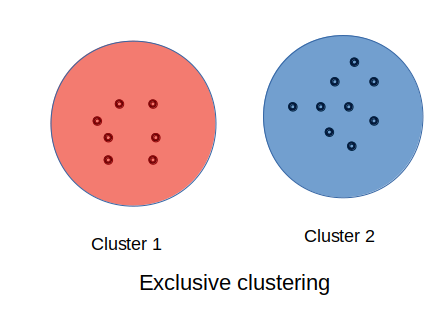

#### Overlapping clustering-

This type of clustering is also called soft cluster.

In overlapping cluster as the name itself suggests that the two clusters overlap each other.

example: C-means clustering

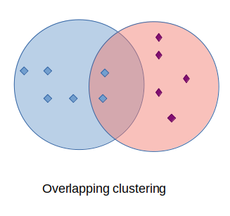

#### Hierarchical clustering-

In hierarchical clustering, various clusters belong to some other parent cluster. In the following diagram we can see that "A" and "B" belong to same cluster. But this cluster is a part of cluster "E" . And both the cluster "E" and "F" belong to cluster "G".

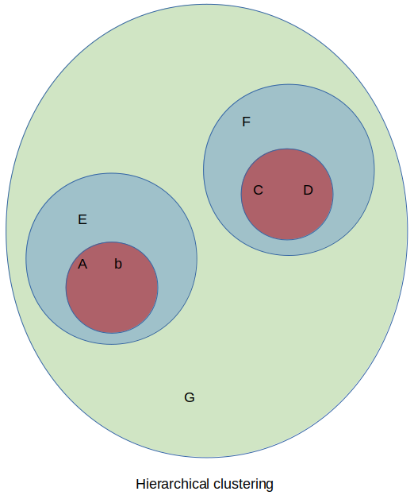

## Steps included-

1. Select the number of clusters(K) to be identified.
2. Randomly select K distint data points, which we are assuming to be centroid of three clusters.

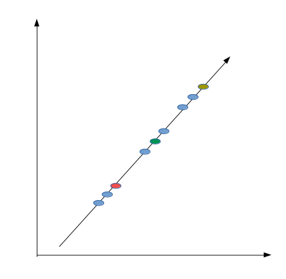

3. Measure the distance between first point and selected centroids.

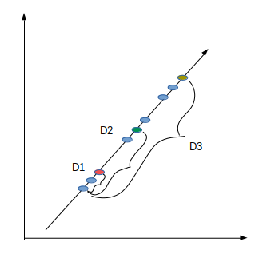

4. Add the first point to the closest centroid. In the given case first point will be assigned to the red centroid.
5. Calculate the mean value of first point and red centroid, consider it as new centroid.
6. Calculate the distances between second point and all the centroids.

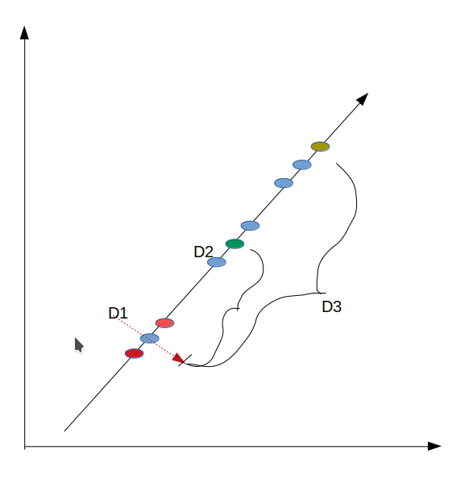

7. This process will go on untill all the pints are assigned to some cluster.
8. The algorithm keeps track of the variance of each cluster. So it repeates the above process and finds the best clusters. In this case we get same cluster for consecutive steps.

## How to set the value of K?

Sometimes it can be observed by looking at the data but this is a rare case and is not reliable. One method to set the value of K is hit and try method. In this method we set various values of K and check which one gives the best results. To check which K gives the best results we plot graph between variance and K. The point at which variance plots an elbow shape,graph, is considered to be the best fit of K.

# Python implementation of K means algorithm

#### importing required libraries

```python
import numpy as np
import pandas as pd
import matplotlib.pyplot as plt
from sklearn import datasets

iris = datasets.load_iris()
print(iris)
X=iris.data
y=iris.target
```

[output not shown]

[output cut: 101 more lines]

[output not shown]

```python
from sklearn.model_selection import train_test_split
(x_train , x_test,y_train, y_test) = train_test_split(X, y, test_size = 0.4)
from sklearn.cluster import KMeans
model = KMeans(n_clusters = 3, random_state=0)

# training
model.fit(x_train, y_train)
```

```
KMeans(algorithm='auto', copy_x=True, init='k-means++', max_iter=300,
    n_clusters=3, n_init=10, n_jobs=None, precompute_distances='auto',
    random_state=0, tol=0.0001, verbose=0)
```

```python
# prediction
y_pred = model.predict(x_test)
print(y_pred)
```

```
[2 2 1 2 2 1 2 0 0 2 0 2 2 1 2 0 2 0 2 2 1 2 2 1 0 2 1 2 0 1 1 0 2 0 0 1 2
 2 2 0 1 2 1 0 0 2 2 2 2 1 2 2 1 2 2 2 0 2 1 2]
```

```python
print("printing predicted classes: ")
for i in y_pred:
    if i == 0:
        print("setosa")
    elif i ==1:
        print("virginica")
    elif i== 2:
        print("versicolor")
```

```
printing predicted classes:
versicolor
versicolor
virginica
versicolor
versicolor
virginica
versicolor
setosa
setosa
versicolor
setosa
versicolor
versicolor
virginica
versicolor
setosa
versicolor
setosa
versicolor
versicolor
virginica
versicolor
versicolor
virginica
setosa
versicolor
virginica
versicolor
setosa
virginica
virginica
setosa
versicolor
setosa
setosa
virginica
versicolor
versicolor
versicolor
setosa
virginica
versicolor
virginica
setosa
setosa
versicolor
versicolor
versicolor
versicolor
virginica
versicolor
versicolor
virginica
versicolor
versicolor
versicolor
setosa
versicolor
virginica
versicolor
```